# CitiBike Use in Washington D.C.

## by: Riddhima Rai

# Introduction

CitiBike is a bike sharing system based out of New York City. It was officially opened in May of 2013 to the boroughs of New York and has expanded to other parts of the United States such as Columbus, Boston, Minneapolis, Washington D.C. and the San Francisco Bay Area. One of the most appealing parts about living in and around major cities such as the ones listed above is the walkability and (mostly) reliable public transportation. CitiBike is a fairly new system and I thought it would be interesting to see how it fits into the public transportation of a metropolitan area such as Washington D.C.

## Data Collection and Management

```python
import pandas as pd

jan_data = pd.read_csv("202201-capitalbikeshare-tripdata.csv");
feb_data = pd.read_csv("202202-capitalbikeshare-tripdata.csv");
march_data = pd.read_csv("202203-capitalbikeshare-tripdata.csv");
april_data = pd.read_csv("202204-capitalbikeshare-tripdata.csv");
```

The first thing I will be doing is concatenating these different data frames from January to April into one to make it easier to analyze and read the information of this quarter.

```python
data_frames = [jan_data, feb_data, march_data, april_data];
q1_data = pd.concat(data_frames);
q1_data.head()
```

|  | ride_id | rideable_type | started_at | ended_at | start_station_name | start_station_id | end_station_name | end_station_id | start_lat | start_lng | end_lat | end_lng | member_casual |
| --- | --- | --- | --- | --- | --- | --- | --- | --- | --- | --- | --- | --- | --- |
| 0 | 1B4445D591115BD9 | classic_bike | 2022-01-06 18:39:28 | 2022-01-06 18:43:03 | Monroe Ave & Leslie Ave | 31087.0 | Potomac Ave & Main Line Blvd | 31910.0 | 38.820932 | -77.053096 | 38.822738 | -77.049265 | member |
| 1 | 7F4A0E2F03EADEB7 | classic_bike | 2022-01-31 19:21:22 | 2022-01-31 19:27:33 | 14th & L St NW | 31283.0 | 10th & G St NW | 31274.0 | 38.903658 | -77.031737 | 38.898243 | -77.026235 | member |
| 2 | 30DD8A84164843AD | classic_bike | 2022-01-07 15:28:39 | 2022-01-07 15:31:01 | 14th & L St NW | 31283.0 | 12th & L St NW | 31251.0 | 38.903658 | -77.031737 | 38.903819 | -77.028400 | member |
| 3 | FC67665D7682D0A6 | classic_bike | 2022-01-27 20:09:25 | 2022-01-27 20:37:02 | New York Ave & Hecht Ave NE | 31518.0 | Nannie Helen Burroughs & Minnesota Ave NE | 31704.0 | 38.915604 | -76.983683 | 38.901385 | -76.941877 | casual |
| 4 | 7854F7CC4F631A1E | classic_bike | 2022-01-07 16:14:28 | 2022-01-07 16:16:13 | Falls Church City Hall / Park Ave & Little Fal... | 32608.0 | Pennsylvania Ave & Park Ave | 32603.0 | 38.885434 | -77.173605 | 38.887403 | -77.176992 | member |

The data provided is already quite clean and gives us a lot of information about the trips. Now, I will clean up the data we have and add to the dataframe so aspects of the trip such as the length and distance can be easily accessible via the dataframe.

I will be creating a total time column by going through the rows and and calculating the difference between the end and start time, and storing it in the dataframe.

```python
currDiff = 0;
timeDiffs = [];
# converting the given data in the started_at and ended_at columns into datetime types
# and then getting their difference
timeDiffs = pd.to_datetime(q1_data['ended_at']) - pd.to_datetime(q1_data['started_at'])

# for loop going through the entired timeDiffs list converting the time to seconds and
# then dividing by 60 to get the total trip time in minutes
for index in range(len(timeDiffs)):
  timeDiffs.iat[index] = timeDiffs.iat[index].seconds/60.00

# adding a new column with the trip time to the dataframe
q1_data['trip_time'] = timeDiffs;

q1_data.head()
```

|  | ride_id | rideable_type | started_at | ended_at | start_station_name | start_station_id | end_station_name | end_station_id | start_lat | start_lng | end_lat | end_lng | member_casual | trip_time |
| --- | --- | --- | --- | --- | --- | --- | --- | --- | --- | --- | --- | --- | --- | --- |
| 0 | 1B4445D591115BD9 | classic_bike | 2022-01-06 18:39:28 | 2022-01-06 18:43:03 | Monroe Ave & Leslie Ave | 31087.0 | Potomac Ave & Main Line Blvd | 31910.0 | 38.820932 | -77.053096 | 38.822738 | -77.049265 | member | 3.583333 |
| 1 | 7F4A0E2F03EADEB7 | classic_bike | 2022-01-31 19:21:22 | 2022-01-31 19:27:33 | 14th & L St NW | 31283.0 | 10th & G St NW | 31274.0 | 38.903658 | -77.031737 | 38.898243 | -77.026235 | member | 6.183333 |
| 2 | 30DD8A84164843AD | classic_bike | 2022-01-07 15:28:39 | 2022-01-07 15:31:01 | 14th & L St NW | 31283.0 | 12th & L St NW | 31251.0 | 38.903658 | -77.031737 | 38.903819 | -77.028400 | member | 2.366667 |
| 3 | FC67665D7682D0A6 | classic_bike | 2022-01-27 20:09:25 | 2022-01-27 20:37:02 | New York Ave & Hecht Ave NE | 31518.0 | Nannie Helen Burroughs & Minnesota Ave NE | 31704.0 | 38.915604 | -76.983683 | 38.901385 | -76.941877 | casual | 27.616667 |
| 4 | 7854F7CC4F631A1E | classic_bike | 2022-01-07 16:14:28 | 2022-01-07 16:16:13 | Falls Church City Hall / Park Ave & Little Fal... | 32608.0 | Pennsylvania Ave & Park Ave | 32603.0 | 38.885434 | -77.173605 | 38.887403 | -77.176992 | member | 1.75 |

Now we have a column that can show us in a clear and fast way how long a certain trip took.

In this dataset we are only given the latitude and longitude of the starting and ending locations. While this choice is more logical concerning an international company, we are only concerned with the locations of the trips conducted in Washington DC. Having the longitude and latitude of two locations is not very telling at first glance; working with metrics that we use everyday makes the process of exploring the data much easier, so some conversion needs to be done. The Haversine formula is used to calculate geographic distance on Earth and using the formula in the form of a function, I will convert the degrees to radians, then to miles and then calculate their difference which will be stored in the dataframe as the distance of the trip.

Information on the Haversine formula and the formula itself can be found at https://www.igismap.com/haversine-formula-calculate-geographic-distance-earth/

```python
from math import radians, cos, sin, asin, sqrt

def haversine(start_lon, start_lat, end_lon, end_lat):
  # converting degrees to radians
  start_lon, start_lat, end_lon, end_lat = map(radians, [start_lon, start_lat, end_lon, end_lat]);

  # calculating difference in longitude and latitude
  diff_lon = end_lon - start_lon;
  diff_lat = end_lat - start_lat;

  # haversince formula
  a = sin(diff_lat/2)**2 + cos(start_lat) * cos(end_lat) * sin(diff_lon/2)**2
  c = 2 * asin(sqrt(a))
  # r represents the radius of the Earth in miles
  r = 3956.87433
  return c * r;


q1_data['distance'] = q1_data.apply(lambda row : haversine(row['start_lng'],
                     row['start_lat'], row['end_lng'], row['end_lat']), axis = 1);

q1_data.head()
```

|  | ride_id | rideable_type | started_at | ended_at | start_station_name | start_station_id | end_station_name | end_station_id | start_lat | start_lng | end_lat | end_lng | member_casual | trip_time | distance |
| --- | --- | --- | --- | --- | --- | --- | --- | --- | --- | --- | --- | --- | --- | --- | --- |
| 0 | 1B4445D591115BD9 | classic_bike | 2022-01-06 18:39:28 | 2022-01-06 18:43:03 | Monroe Ave & Leslie Ave | 31087.0 | Potomac Ave & Main Line Blvd | 31910.0 | 38.820932 | -77.053096 | 38.822738 | -77.049265 | member | 3.583333 | 0.240924 |
| 1 | 7F4A0E2F03EADEB7 | classic_bike | 2022-01-31 19:21:22 | 2022-01-31 19:27:33 | 14th & L St NW | 31283.0 | 10th & G St NW | 31274.0 | 38.903658 | -77.031737 | 38.898243 | -77.026235 | member | 6.183333 | 0.476718 |
| 2 | 30DD8A84164843AD | classic_bike | 2022-01-07 15:28:39 | 2022-01-07 15:31:01 | 14th & L St NW | 31283.0 | 12th & L St NW | 31251.0 | 38.903658 | -77.031737 | 38.903819 | -77.028400 | member | 2.366667 | 0.179685 |
| 3 | FC67665D7682D0A6 | classic_bike | 2022-01-27 20:09:25 | 2022-01-27 20:37:02 | New York Ave & Hecht Ave NE | 31518.0 | Nannie Helen Burroughs & Minnesota Ave NE | 31704.0 | 38.915604 | -76.983683 | 38.901385 | -76.941877 | casual | 27.616667 | 2.451859 |
| 4 | 7854F7CC4F631A1E | classic_bike | 2022-01-07 16:14:28 | 2022-01-07 16:16:13 | Falls Church City Hall / Park Ave & Little Fal... | 32608.0 | Pennsylvania Ave & Park Ave | 32603.0 | 38.885434 | -77.173605 | 38.887403 | -77.176992 | member | 1.75 | 0.227246 |

## Exploratory Data Analysis

Now that we’ve cleaned up the data to be in a more digestible way, it’s time to see if we can observe any trends within the dataset. I will begin my analysis by plotting the distance ridden against the type of membership of the rider as well as trip time against the type of membership. I’m curious to see what goes into the criteria of a rider choosing to be a registered member compared to a casual rider. Is it the typical distance traveled, the amount of time spent on the bike, or some other factor not included in the dataset?

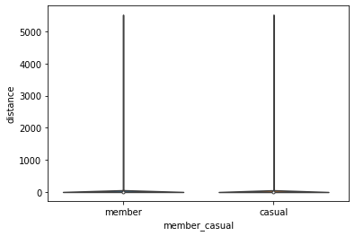

```python
import numpy as np
import matplotlib as mpl
import matplotlib.pyplot as plt
import seaborn as sns

sns.violinplot(x='member_casual', y='distance', data = q1_data, showmeans =True)
```

Looking at the violin plot created, it’s clear that there were some outliers in the data. Realistically, no one is riding 5000 miles on a CitiBike. To account for these outliers, we won’t consider any data points that have over 10 miles in the distance column. With removing these outliers, we will also be able to get a better look at the distribution and see if there is a trend between type of membership and distance traveled by CitiBike.

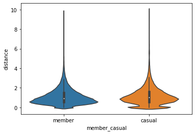

```python
q1_data_plot = q1_data[q1_data['distance'] < 10];
sns.violinplot(x='member_casual', y='distance', data = q1_data_plot)
```

With this new violin plot, we get a better look at the distribution of the distance that a CitiBike rides and its correlation to if the rider is a member or not. At first glance there is not a significant difference in the distribution. This is to be expected, CitiBikes are meant to be a way to get from one destination to another so it is expected for distances to remain quite small.

We have the CitiBike data from the past 4 months, and I wanted to see the effect that the change in the months and the weather may have had on the frequency that people take CitiBikes to get around. So, I am going to sort my data points by date and plot the frequency of rides over time. Before plotting the data, I am expecting there to be some sort of correlation, specifically an increase in the frequency of CitiBike rides. My null hypothesis is that there would be no correlation between time passing and the frequency of which CitiBikes are being ridden. The alternative would be that there is a correlation significantly different from 0. Before analzying any data, my intuition tells me that there would be an upwards trend in the frequency as I anticipate that as the weather gets warmer in Washington D.C., the more people would be open to using CitiBike as a mode of transportation.

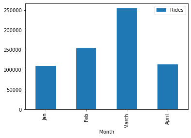

```python
# Using the started_at times and sorting the dataframe in order of time
jan_frequency = len(jan_data);
feb_frequency = len(feb_data);
march_frequency = len(march_data);
april_frequency = len(april_data);

total_rides = pd.DataFrame({'Month': ['Jan', 'Feb', 'March','April'], 'Rides': [jan_frequency, feb_frequency, march_frequency, april_frequency]});

ax = total_rides.plot.bar(x='Month', y ='Rides');
```